# Food web grid search and metabolism

Krista Kraskura

2024-08-26

1. One limitation in this study, is the unknown/estimated food web:

**Question:** how sensitive model predictions are to changes in the food web

**Solution:** perform grid search to modulate food web to see the effects

2. Sun et al 2022 found that model outputs were the most sensitive to changes in:
- ventilation rate
- feeding rate
- aqueous chemical transfer efficiency %
- dietary chemical transfer efficiency %

**Problem:** these parameters could be species specific, but the empirical data are scarce. Additionally, Sun et al 2022 presents that benthic fish are more sensitive to exclusion of dietary PFAS uptake. Benthic fish also tend to have lower metabolism, and therefore, their proportional gill uptake may be lower.

**Question:** Does species specific metabolism improve the model output? if yes, how much better?

**Solution:** run the model with species specific RMR values obtained from fishbase.org and other sources.

3. What are the key parameters that field monitoring could focus on to obtain the most reliable PFAS predictions.

### PART 1: Food web grid search:

[output not shown]

[figure not shown]

|  | Sed | Phy | Pry | Bgl | Bas |
| --- | --- | --- | --- | --- | --- |
| Phy | 1 | 0 | 0 | 0 | 0 |
| Pry | 1 | 0 | 0 | 0 | 0 |
| Bgl | 0 | 0 | 1 | 0 | 0 |
| Bas | 0 | 0 | 0 | 1 | 0 |

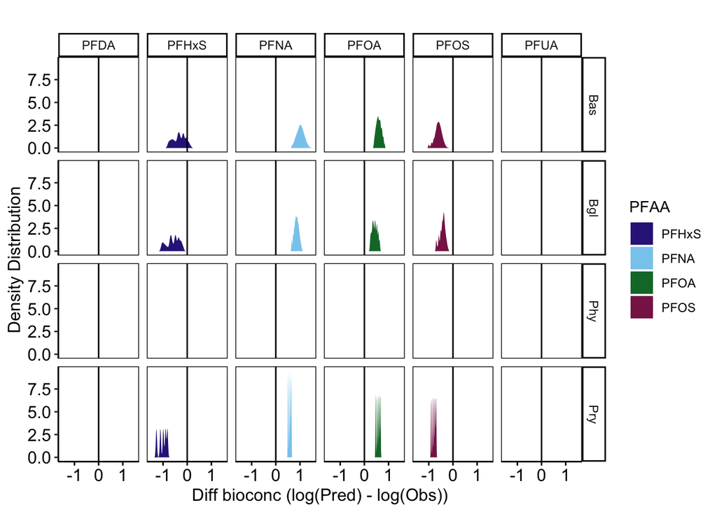

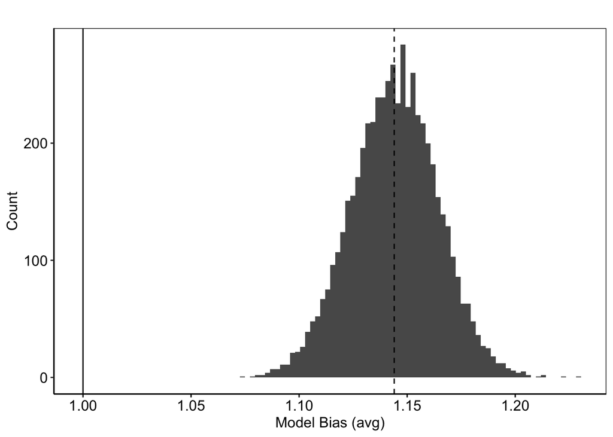

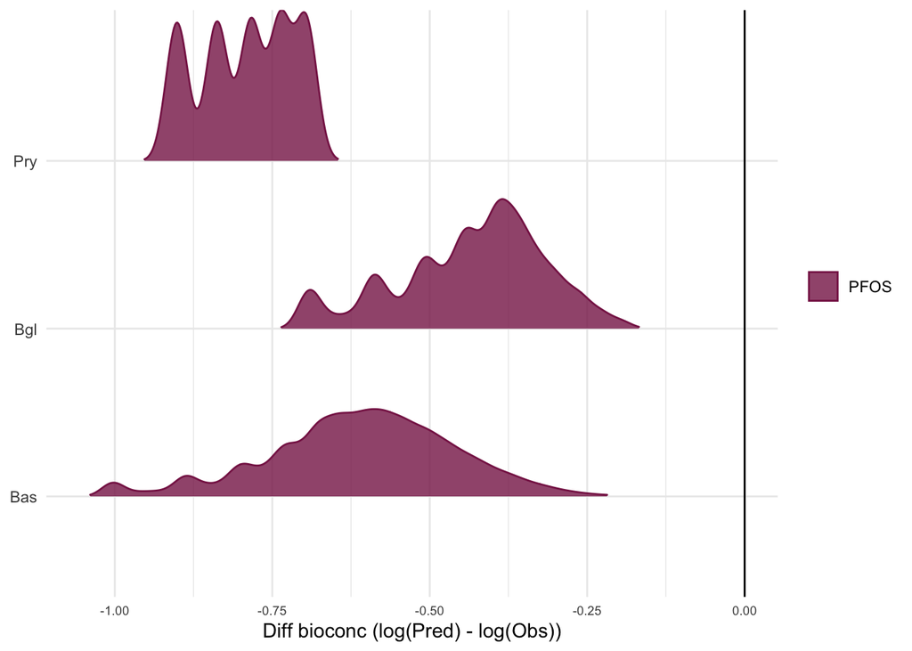

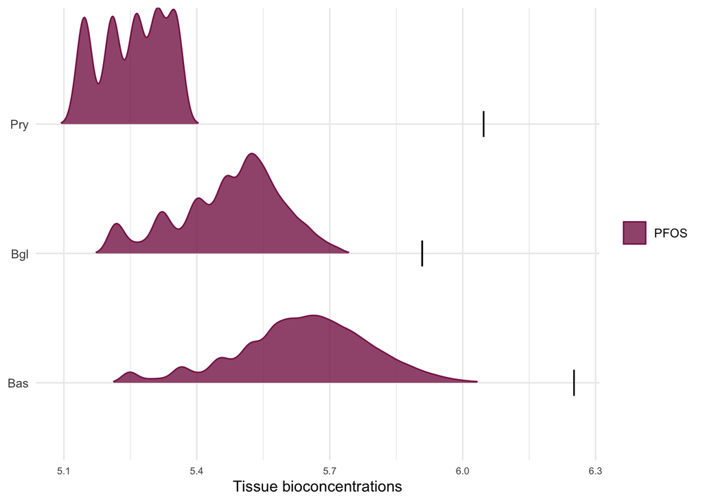

### Error estimated for modeled diet

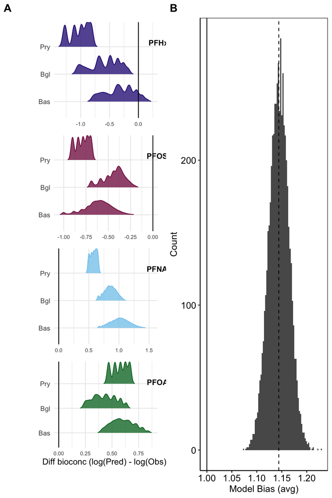

Figure 1.

### PART2: Species specific metabolism:

*Species abbrev. : Metabolism mgO2/day

- Pum 110.9264324
- Pry 24.81153852
- Dac 50.0519863
- Swa 19.45794798
- Dar 9.8568
- Min 11.8656
- Mad 23.63965131
- Chu 107.98848
- Kil 17.77361342
- Bas 1081.441999 (adult WG)
- Fal 18.72309445
- Bgl 348.3142029
- Bas 85.89386534 (juvie JBA)

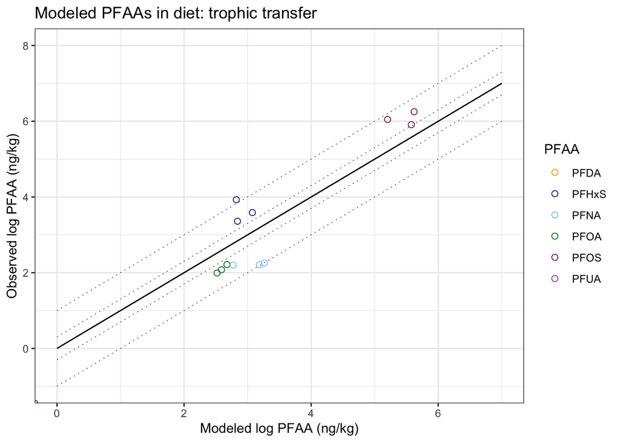

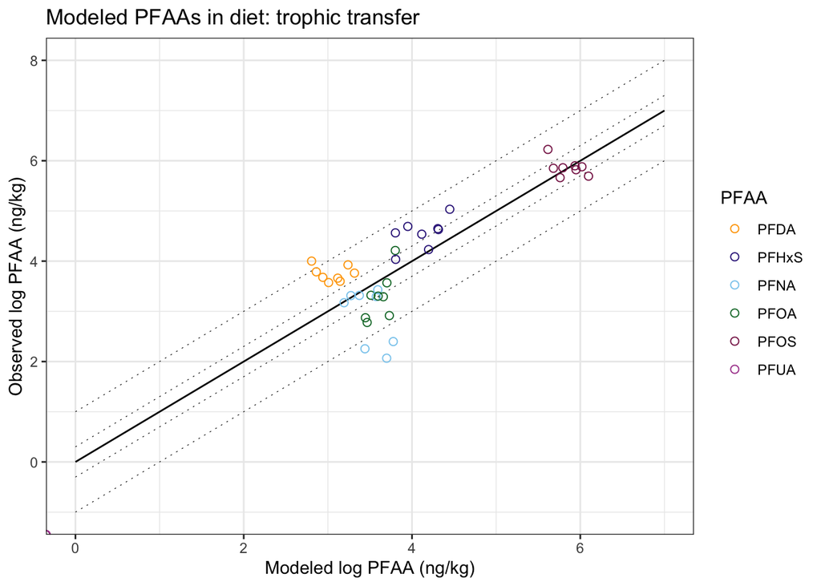

### Error estimates and model bias

Table 1: Average model bias, addition of species metabolism

[output not shown]

Table 2: Average model bias by PFAA, addition of species metabolism

| System | Model | Data type | PFDA | PFHxS | PFNA | PFOA | PFOS | PFUA |
| --- | --- | --- | --- | --- | --- | --- | --- | --- |
| Willow Grove | trophic transfer | median values | NaN | 1.12 | 0.73 | 0.76 | 1.12 | NaN |
| JBA-summer | trophic transfer | median values | 1.24 | 1.08 | 0.90 | 0.96 | 1.01 | NaN |
| JBA-spring | trophic transfer | median values | 1.28 | 1.09 | 1.02 | 0.92 | 1.07 | NaN |

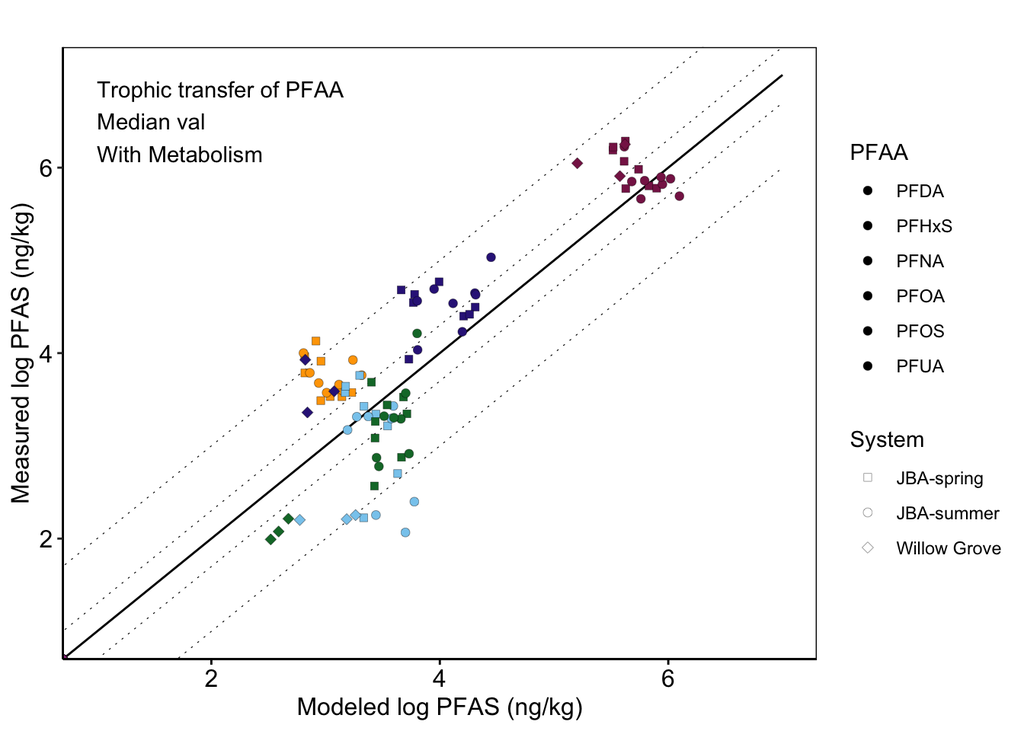

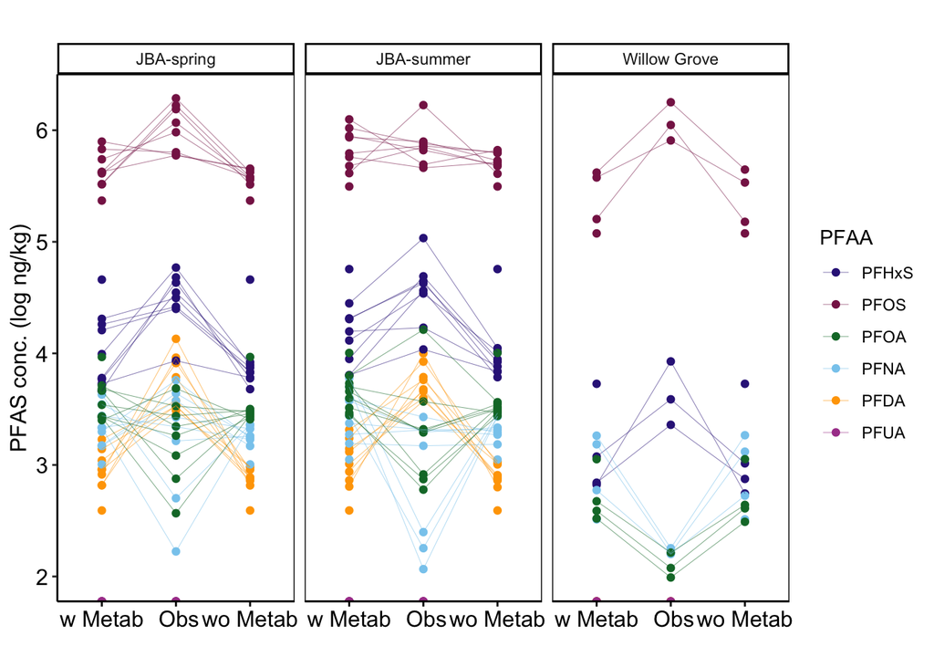

```
## [1] TRUE
```

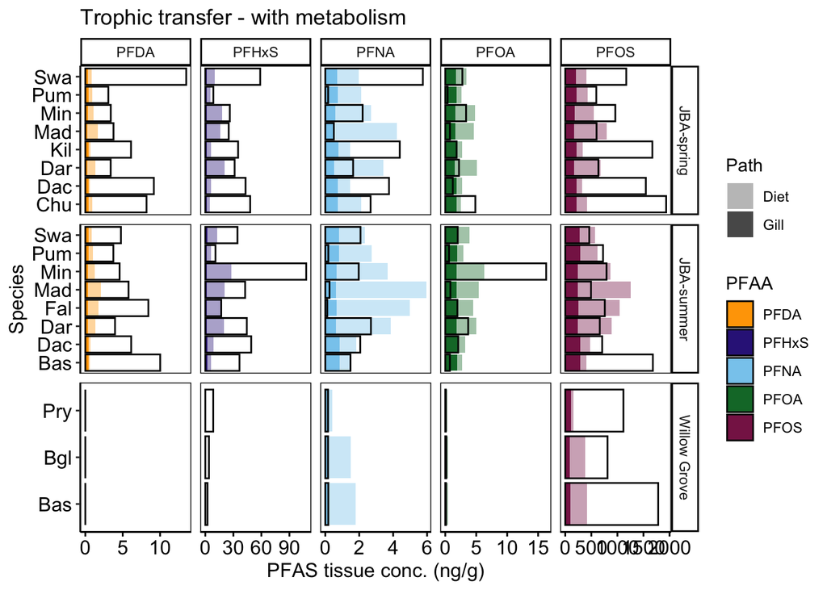